# purrr_gridsearch_blog.Rmd

MDH

12/13/2017

# Hypurrr-ameter Search with Purrr and Future

#### See executable notebook of this post at this [Github repo](https://github.com/mrecos/hypurrr-ameters)!

I have had a thing lately with aggregating analyses into sequences of `purrr::map()` function calls and dense `tibbles`. If I see a loop - `map()` it. Have many outputs - well then put it in a `tibble`. Better yet, apply a sequence of functions over multiple model outputs, put them in a `tibble` and `map()` it! That is the basic approach I take here for modeling over a sequence of random hyperparameters (Hypurrr-ameters???); plus using `future` to do it in parallel. The idea for the code in this post came after an unsettled night of dreaming in the combinatoric magnitude of repeated K-folds CV over the hyperparameters for a multilayer perceptron. anyway…

“Correlated Hyperparameters”" - Zoroaster Clavis Artis 1738 (inspired by @vboykis #devart)

[figure not shown]

- **Objective**: Demonstrate an approach to randomly searching over model hyperparameters in parallel storing the results in a tibble.
- **Pre-knowledge**: Beginner to Moderate R; introductory modeling concepts; Tidy/Purrr framework
- **Software**: `R 3.4.0`, `tidyverse 1.2.1` (contains `tibble`, `dplyr`, `purrr`, `tidyr`, and `ggplot2`), `rsample 0.0.2`, `future 1.6.2`

[figure not shown]

## Optimizing hyperparameters

Hyperparameters are the tuning knobs for statistical/machine learning models. Basic models such as linear regression and GLM family models don’t typically have hyperparameters, but once you get into Ridge or Lasso regression and GAMs there are parts of the model that need tuning (e.g. penalties or smoothers). Methods such as Random Forest or Gradient Boosting, Neural Networks, and Gaussian Processes have even more tuning knobs and even less theory for how they should be set. Setting such hyperparameters can be a dark-art and require experience and a bit of faith. However, even with experience in these matters it is rarely clear what combination of hyperparameters will lead to the best out-of-sample prediction on a given dataset. For this reason, it is often desired to test over a range of hyperparameters to find the best pairing.

The major issue of searching hyperparameters is the computational cost of searching a wide range of values to avoid local minima, testing over a fine enough grid to avoid over-shooting minima, and estimating variance via bootstrapping or K-folds CV. For example, a model with two hyperparameters tested over K = 10 folds CV for the values of each hyperparameter equates to 10 x 10 x 10 = 1,000 models! A third hyperparameter is another order of magnitude. Needless to say, this adds up fast. While a handful or algorithms and approaches have been developed to deal with this, the most common method is a basic grid-search or a random search across a sequence of hyperparameters. In this example, I employ a random search, but changing it to grid-search is simple.

[figure not shown]

## `Purrr::map()` and `tibble`

To preform hyperparameter search in a table, we can use the power of [`purrr`](http://purrr.tidyverse.org/) to do the heavy lifting and the [`tibble`](http://tibble.tidyverse.org/) to store the results/computations. The `tibble` is much like the basic `data.frame` in many respects, but differing in some key ways that allow for the `purrr` idiom to really flourish. One of those differences is that the `tibble` is very accommodating to dealing with all sorts of data stuffed into the grid cells. Often referred to a list-column, this behavior allows the each cell in a column to store lists, which themselves can contain any R data structure like lists, data,frames, tibbles, data, functions, etc… The toy example below shows how typical numeric and character data are stored in `Col_A` and `Col_B` while `Col_C` is a list with three elements, one for each row, containing the character vector `"X","Y","Z"`. Finally, `Col_D` is a list that contains three elements (rows), each of which is also a list and contains three elements that are the XYZ character vector. Recursion!

```r
library("tidyverse")
list_col_example <- tibble(Col_A = c(1,2,3),
                           Col_B = c("A","B","C"),
                           Col_C = list(c("X","Y","Z")),
                           Col_D = list(Col_C))
print(list_col_example)
```

```
## # A tibble: 3 x 4
##   Col_A Col_B     Col_C      Col_D
##   <dbl> <chr>    <list>     <list>
## 1     1     A <chr [3]> <list [3]>
## 2     2     B <chr [3]> <list [3]>
## 3     3     C <chr [3]> <list [3]>
```

This recursive storage is really powerful! In this example, we take advantage of the list-column to store hyperparameter values that we then loop over to create and evaluate numerous models. Specifically, we will use the family of `map()` functions in `purrr` to iterate functions over elements of a list-column. If you are familiar with the world of `*apply()` functions, this is similar, but executed in a much more consistent manner and plays very well with other components of the [Tidyverse](https://www.tidyverse.org/). If you don’t know much about `apply()` or `map()`, check out the [great tutorials](https://jennybc.github.io/purrr-tutorial/index.html) by [Jenny Bryan](https://twitter.com/JennyBryan) to see functional programming in action. Here are two examples of using `map()`. First, `map()` is used to apply the `paste()` function to the list-column `Col_C` along with the added argument of `collapse = ''`. The output, `Map_Col_1` is itself a list of character vectors just like `Col_C`. However, if we know the data type of the desired output, we can apply a type specific `map_chr()` function to cast the output to a character string in `Map_Col_2`. Pretty cool!

[output not shown]

[figure not shown]

```r
list_col_example <- list_col_example %>%
  mutate(Map_Col_1 = map(Col_C, paste, collapse = ''),
         Map_Col_2 = map_chr(Col_C, paste, collapse = ''))
print(list_col_example)
```

## Nesting a `tibble` with `tidyr::nest()`

The final piece of learning that builds up to the hyperparameter example is using the `nest()` function from the `tidyr` package to collapse table columns into list columns. This is similar in concept to grouping rows in a table based on values and returns a table of the groups within a new column. An example of how this works is well illustrated with the classic `iris` dataset. In `iris` you have four columns plant part measurements and one column with the iris flower species name; `Setosa`, `Versicolor`, and `Virginica`. There are 50 rows for each species. To collapse the data.frame into a `tibble` with one row for each species and one list-column containing a dataframe on the 50 examples of that species, you simply use the `nest()` function and tell it what column *not* to include in the group; here it is `Species`

```r
head(iris)
```

```
##   Sepal.Length Sepal.Width Petal.Length Petal.Width Species
## 1          5.1         3.5          1.4         0.2  setosa
## 2          4.9         3.0          1.4         0.2  setosa
## 3          4.7         3.2          1.3         0.2  setosa
## 4          4.6         3.1          1.5         0.2  setosa
## 5          5.0         3.6          1.4         0.2  setosa
## 6          5.4         3.9          1.7         0.4  setosa
```

```r
nest_example <- iris %>%
  nest(-Species) %>%
  as.tibble()
print(nest_example)
```

```
## # A tibble: 3 x 2
##      Species                  data
##       <fctr>                <list>
## 1     setosa <data.frame [50 x 4]>
## 2 versicolor <data.frame [50 x 4]>
## 3  virginica <data.frame [50 x 4]>
```

cite: https://www.shareicon.net/plant-iris-blossom-nature-bloom-spring-floral-717702

[figure not shown]

To close the loop on how you might use a nested `tibble` with `map()` for modeling, we can use the example above to show how you can run models on groups. We will use a simple linear regression with `lm()` in a small helper function to model each species `Sepal.Length` by the other three measurements. (Note: this is just an example and modeling groups without pooling is probably a bad idea.). The use of a helper function is a really handy way to write a minimal bit of code that acts as a go-between from `map()` to your intended function. The very next line after the model is fit, we use `map_dbl()` to apply a root mean squared errors (RMSE) on the model fit to return a numeric value. The result of this is a `tibble` with a list-column names `model` that contains the entire `lm()` fit object and another column with a goodness-of-fit metric.

```r
lm_helper <- function(data){
  lm1 <- lm(Sepal.Length ~ ., data = data)
}

nest_example2 <- nest_example %>%
  mutate(model = map(data, lm_helper),
         RMSE  = map_dbl(model, ~ sqrt(mean((.$residuals)^2))))
print(nest_example2)
```

```
## # A tibble: 3 x 4
##      Species                  data    model      RMSE
##       <fctr>                <list>   <list>     <dbl>
## 1     setosa <data.frame [50 x 4]> <S3: lm> 0.2274488
## 2 versicolor <data.frame [50 x 4]> <S3: lm> 0.3211353
## 3  virginica <data.frame [50 x 4]> <S3: lm> 0.3050135
```

## Mapping over Hypurrr-ameters

**Quick Warning:** This post uses the Random Forest algorithm is these examples. I picked RF because it is very common, an accurate & tunable model, and it has the built in test function so I could train and test at the same time. The downside is that RF is a **memory hog**! Especially here where I need to keep each tree to get the benefit of test set prediction and store it in the `tibble`. Running the below code over 200 hyperparameters pairs maxed out 32 Gb of ram. If you have a basic laptop, try 5 to 25 hyperparameter pairs to get the idea of what is going.

```r
library("randomForest")
library("rsample")
library("viridis")
```

```r
data <- MASS::Boston
searches <- 10 # number of random grid searches
max_trees <- 500
cv_folds <- 5

model_fits <- seq_len(searches) %>%
  tibble(
    id = .,
    ntree = sample(c(1,seq(25,max_trees,25)),length(id),replace = T),
    mtry  = sample(seq(1,ncol(data)-1,1),length(id),replace = T)
  )
print(model_fits)
```

```
## # A tibble: 10 x 3
##       id ntree  mtry
##    <int> <dbl> <dbl>
##  1     1   225    13
##  2     2   325    13
##  3     3   150     8
##  4     4   450    13
##  5     5   150     2
##  6     6   150     9
##  7     7   200     4
##  8     8   375    11
##  9     9   350     5
## 10    10     1     7
```

The next big step in the process is to `nest` each hyperparameter pair into its own small 1x2 `tibble`. The philosophy is that each of these hyperparameter pair `tibbles` acts as the nugget that we keep applying the `map()` function over to conduct this whole analysis! In the code below we simply exclude the `id` column from the nesting and assign the name `params` to the new aggregated column of hyperparameters

```r
model_fits <- model_fits %>%
  nest(-id, .key = "params")
print(model_fits)
```

```
## # A tibble: 10 x 2
##       id           params
##    <int>           <list>
##  1     1 <tibble [1 x 2]>
##  2     2 <tibble [1 x 2]>
##  3     3 <tibble [1 x 2]>
##  4     4 <tibble [1 x 2]>
##  5     5 <tibble [1 x 2]>
##  6     6 <tibble [1 x 2]>
##  7     7 <tibble [1 x 2]>
##  8     8 <tibble [1 x 2]>
##  9     9 <tibble [1 x 2]>
## 10    10 <tibble [1 x 2]>
```

Now the real work starts. First we have three new helper functions.

```r
# splits CV objects into test, train, and parameter pairs
cv_helper <- function(data, params){
  d <- data %>%
    mutate(mtry  = params$mtry,
           ntree = params$ntree,
           train = map(splits, rsample::analysis),
           test  = map(splits, rsample::assessment)) %>%
    select(-splits)
}
# the main modeling helper. Trains and Tests RF model on each CV fold
rf_helper  <- function(folds){
  rf_model <- function(train,mtry,ntree,test){
    xtest  <- dplyr::select(test,-medv)
    ytest  <- test$medv
    m1 <- randomForest(medv ~., data=train,mtry=mtry,ntree=ntree,
                       xtest=xtest,ytest=ytest,keep.forest=TRUE)
  }
  # prediction function can go here and map in below if need be
  m <- folds %>%
    mutate(model = pmap(list(train,mtry,ntree,test),rf_model))
}
# Extracts test set MSE from RF Model and averages MSE from each ntree
MSE_helper <- function(model){
  err_helper <- function(rf){
    mse <- mean(rf$test$mse)
  }
  m2 <- model %>%
    mutate(mse = map_dbl(model, err_helper)) %>%
    dplyr::select(mse)
  mean(m2$mse)
}
```

The helper functions are a great way to abstract a bit of the specifics of bridging to other functions. For example, `MSE_helper()` function could probably be squeezed into the call to `map()`, but it would be a little bit messy because you would have to put a `map()` within a `map()`. In my mind, it makes sense to write a small function to take care of that. The other helper functions do various things, but I try to stick with each function only doing one thing and pertaining to one `map()` function. To write a bloated helper function that takes care of a bunch of steps sort of defeats the purpose of mapping over the analysis. Below is the `map()` sequence. Each step is detailed following the code block.

```r
model_fits <- model_fits %>%
   mutate(splits = list(rsample::vfold_cv(data,cv_folds)), # same resamples in each
          folds  = map2(splits, params, cv_helper),        # split folds into test/train
          model  = map(folds, rf_helper),                  # fit RF and test
          mse    = map_dbl(model, MSE_helper))             # extract out-of-fold MSE
```

#### Split the data into CV folds with `rsample`

Once we have the data shaped and helper functions built, we can start to map our analysis over each row. First I use the `vfold_cv()` function from the `rsample` package to create a cross-validation folds (K = `cv_folds`). The slight trick is that I do this first and put it in a `list` so that the folds of each row (and `params` pair) is the same splits of the data. This is critical if you want to compare outcomes across hyperparameter pairs. Otherwise, each `params` pair is executed on a different set of data… and that is not good.

#### Extract test and train data from Splits

Next we use `map2()` to send two columns `splits` and `params` to the `cv_helper` function to divide the `split` object into `test` and `train` datasets, carrying over the hyperparameter pairs. An important note here is that Max Kuhn at Rstudio has been busy at work with the `caret`, `rsample`, and `recipe` packages to streamline all parts of this process. You could utilize these packages more effectively in this pipeline. I did it this way to expose the modeling steps.

#### Fit and test CV folds with `RandomForest`

Then the `tibble` in the `folds` column containing the `test`, `train`, and hyperparameter pair is sent to the `rf_helper` to fit the data on that hyperparameter pair for each of the folds in the CV split data sets. Noting that we save a step her because the `randomForest()` function allows you to not only train the model, but also test it at the same time! Supplying a `test` set of data and outcome results in the randomForest model object containing an out-of-sample error rate for each model on each CV fold.

#### Extract Out-of-sample Mean Squared Error from model fit

```r
mean(model_fits$mse)
```

```
## [1] 13.84958
```

So this example leads to an average MSE of `13.85` across all random hyperparameter selections. This is about `$3720` of median owner-occupied home value. Below we tabulate the mean out-of-fold mse for each hyperparameter pair. The best pair of `ntree` = `150` and `mtry` = `9` for an error of `$3430`.

Selecting only the `mtry`, `ntree`, & `mse` columns for display.

```r
print(mse_pairs)
```

```
## # A tibble: 10 x 4
##       id  mtry ntree   mse
##    <int> <dbl> <dbl> <dbl>
##  1     1    13   225 12.56
##  2     2    13   325 12.46
##  3     3     8   150 12.10
##  4     4    13   450 12.34
##  5     5     2   150 14.96
##  6     6     9   150 11.79
##  7     7     4   200 12.34
##  8     8    11   375 11.96
##  9     9     5   350 12.16
## 10    10     7     1 25.81
```

#### Plotting hyperparameter grid

The thing about hyperparameters is they are correlated. There is no one best `mtry` and an independently best `ntree`. This is the reason why there is so much attention paid to various ways to search for the best hyperparameter set and why there is little common wisdom about what sets will be best for a given dataset; it is a mutli-dimensional optimization task. One good way to get a sense of this is to plot the hyperparameters on a grid and symbolize the magnitude of your metric or loss/cost function for each evaluated hyperparameter pair. Here is one possible way to do so.

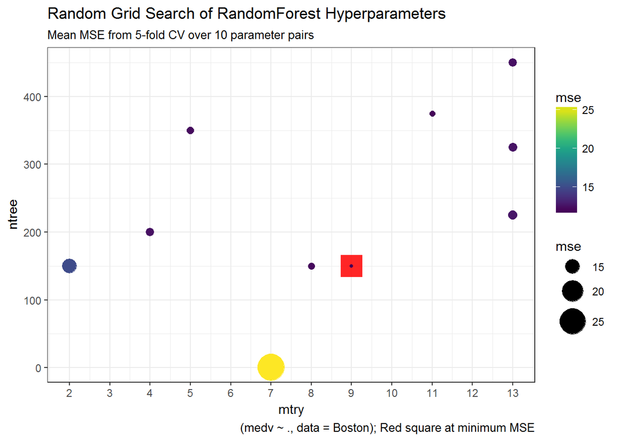

```r
# reshape for plotting
MSE_plot <- model_fits %>%
  mutate(mtry   = map_dbl(params, "mtry"),
         ntree  = map_dbl(params, "ntree")) %>%
  dplyr::select(mtry, ntree, mse) %>%
  group_by(mtry, ntree) %>%
  summarise(mse = mean(mse))
# plot results
ggplot() +
  geom_point(data = filter(MSE_plot, mse == min(MSE_plot$mse)),
             aes(x=mtry,y=ntree), color = "red",
             size = 8, shape = 15, alpha = 0.85) +
  geom_point(data = MSE_plot, aes(x=mtry,y=ntree, size = mse, color = mse)) +
  scale_size(range = c(1,10)) +
  scale_x_continuous(breaks = scales::pretty_breaks(n=ncol(data)-1)) +
  scale_color_viridis() +
  labs(title = "Random Grid Search of RandomForest Hyperparameters",
       subtitle = paste0("Mean MSE from ", cv_folds, "-fold CV over ",
                         searches, " parameter pairs"),
       caption = "(medv ~ ., data = Boston); Red square at minimum MSE") +
  theme_bw() +
  theme(
    text = element_text(family = "Iosevka")
  )
```

As noted in the warning above, I do not recommend running this on more than 50 or some hyperparameter pairs unless you plan to wait a while and have more than 16Gb of available ram. If you are doing real science here, its worth the wait, but not for a code example in a blog post! Below is a plot of running this for 200 hyperparameter pairs if you are curious.

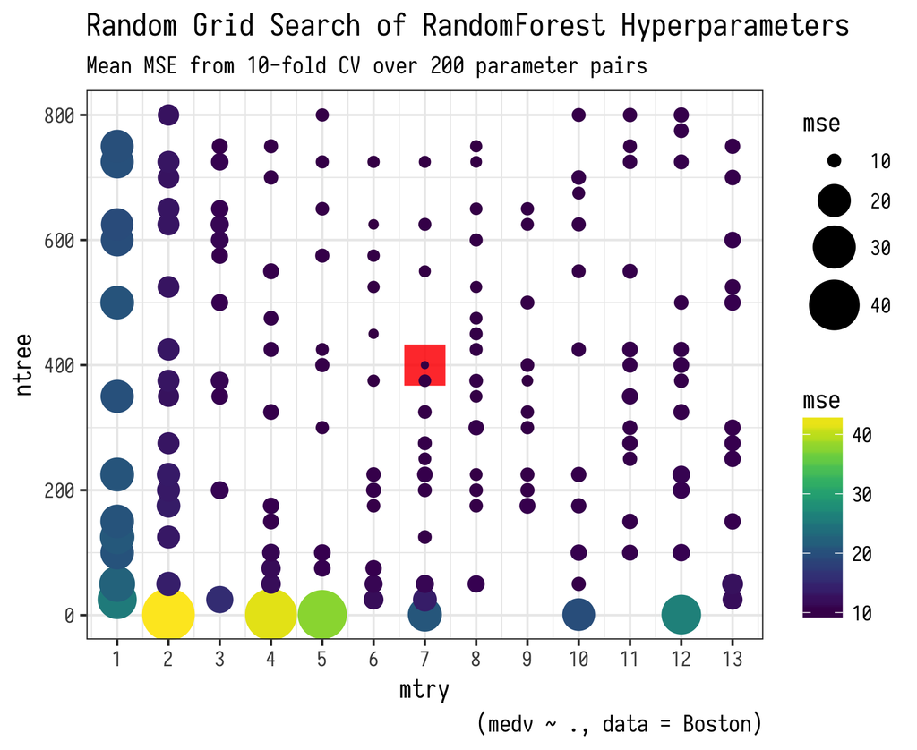

## Parallelize with `future`!!!

Mapping over the rows of a `tibble` is an interesting way to execute a number of similar functions in sequence. However, since the evaluation of each hyperparameter pair is independent of each other, it makes the perfect scenario to parallelize the sequence. Fortunately, the `future` package by [Henrik Bengtsson](https://twitter.com/henrikbengtsson) gives us the ability to easily modify the `purrr::map()` code to take advantage of a parallel backend. I don’t have the time or knowledge to give a formal introduction to the `future` package, but I can show you a quick way to use it. To read more about the `future` package check out [this vignette](https://cran.r-project.org/web/packages/future/vignettes/future-1-overview.html)

The core idea of the `future` package is that it allows you to write code that will be evaluated in the future; hence the name. It is a bit like a queuing system that can use a bunch of different methods to queue and execute your code in a synchronous or asynchronous sequence that takes advantage of available computational resources. I know I am not doing justice here! The main part of setting up your code is to choose a `future::plan()`. The `plan` is the method by which you plan to queue code and execute it as cores become available. The two `plans` that I have used are `multisession` and `multiprocess`. The former is available on all platforms and creates a bunch of background R sessions to take up the work. The latter is a bit more like traditional multicore parallelization and uses the current R session to execute everything. I will use `multisession` here.

```r
library("future")
future::plan(multisession) # <- setup parallel
```

If you get even a little into the [future intro vignette](https://cran.r-project.org/web/packages/future/vignettes/future-1-overview.html), you will see that there is a bit of new syntax used to setup code for parallel evaluation. Most notably is the `%<-%` assignment operator. However, since we are deploying this into an existing `purrr::map()` sequence, we will use a different approach to send functions to the queue. The code block below is nearly identical except for changes to the three lines with comments. The three main changes are:

1. Start a new `mutate()` call after the folds are created
2. The `map()` function is now wrapped in a `future::future()` call; `~future::future(rf_helper(.x))`
3. Another new `mutate()` call is made to collected the values from the `future` R sessions and continue on to the mse error extraction.

So that’s it! The hardest part was starting a `mutate()` call and the little but of syntax to wrap the function in the `map()` call into a `future::future()` call. Note, I use `future::future()` instead of just `future()` because I think being explicit about the package/environment is go, but either will do. Also, within the `future()` wrapped call to `rf_helper()` and `future::value()` I need to include the `.x` as the place holder for the data that is the first argument in the `map()` function; that is `folds` and `model` respectively.

```r
model_fits <- seq_len(searches) %>%
  tibble(id    = .,
         ntree = sample(c(1,seq(25,max_trees,25)),length(id),replace = T),
         mtry  = sample(seq(1,ncol(data)-1,1),length(id),replace = T)) %>%
  nest(-id, .key = "params") %>%
  mutate(folds  = list(rsample::vfold_cv(data,cv_folds)),
         folds  = map2(folds, params, cv_helper)) %>%             # <- start new mutate()
  mutate(model  = map(folds, ~future::future(rf_helper(.x)))) %>% # <- send rf_helper call to queue
  mutate(model  = map(model, ~future::value(.x)),                 # <- collect the values of rf_helper
         mse    = map_dbl(model, MSE_helper))
```

After that fires off on all cylinders, the `model_fits` `tibble` is the same as the non-parallel version and the plot function is identical. I won’t guarantee that given your system, model, ramm that this will be faster; with randomforest memory is usually the bottleneck. However, when I did some tests across a few hundred hyperparameter evaluations, I saw a approximate 14% decrease in execution time.

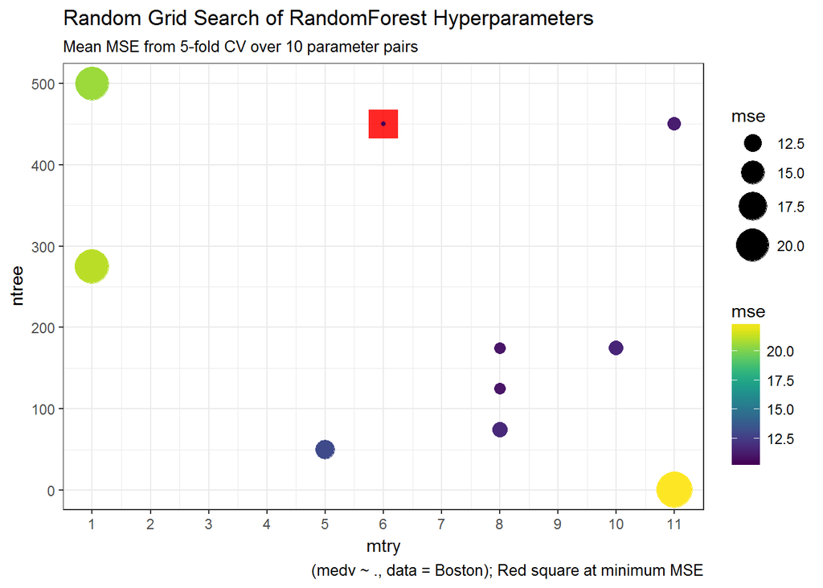

So that’s it! Let your mind run wild about the sort of models/simulations/experiments that you can run in parallel while mapping across a table of values. The result is an incredibly readable and super compact data structure. There is something satisfying (or perhaps insane…) about completing an entire analysis from data ingest, clean-up, modeling, and inference in a short series of `purrr::map()` calls and then seeing the entire process stored in one table. A purrr-fect way to tidy up your code!